# Effects of Weather on Predicted Motor Vehicle Accident Reports in New York City Using Supervised Machine Learning

## Andrew Smith, April 10th, 2023

## 1 Introduction

### 1.1 Project Scope

This project attempts to study the effects of regional weather data on motor vehicle accidents for New York City between the dates of October 12th, 2012 and December 31st, 2015. Correlations between the various weather features will be analyzed with respect to themselves and with the aggregate count for the reported motor vehicle accidents to determine which weather features can be excluded from analysis, and how the general weather trends impact the number of accidents by first order approximation. A machine learning algorithm will be selected, trained, and tested on the labelled data to determine the ability of such an algorithm to predict the liklihood of motor vehicle accidents. The applications for such analysis are numerous, including but not limited to warning drivers of hazardous weather conditions, preparing emergency services for influx of motor vehicle accidents using weather forecasting, determining monetary effects on weather conditions for insurance companies, etc.

### 1.2 Hypothesis

The hypothesis for this project is to show (1) that days with poor weather conditions will lead to an increase in motor vehicle accidents, and that (2) the number of total motor vehicle accidents can be roughly predicted using a weather forecast. A definition of "poor" weather conditions are to be defined as above average precipitation, wind speed, and cloud coverage, as well as sufficiently high or low pressure and temperatures for the day. The occurence of different weather events such as rain, fog, thunderstorms, and snow are also considered poor weather conditions. The numerical ranges for poor weather condition classification will be determine later. The second part of this report will involve using a classification algorithm to predict whether a given days weather features (such as temperature, pressure, and precipitation) will result in high, average, or low amount of total reported vehicle accidents for the day. The method for aggregating the number of reported accidents into discrete categories is discussed later.

### 1.3 Raw Data Sources

All modules and methods used for this report are shown below. The raw data for the daily weather statistics as well as the complete motor vehicle accident logs are also shown below.

```python
import numpy as np
from numpy.random import default_rng
import pandas as pd
import seaborn as sns
from sklearn.tree import DecisionTreeClassifier
from sklearn.neighbors import KNeighborsClassifier
from sklearn import datasets
from sklearn.model_selection import train_test_split
from sklearn.utils import shuffle
from sklearn.metrics import confusion_matrix, f1_score, balanced_accuracy_score
from sklearn.pipeline import make_pipeline
from sklearn.preprocessing import StandardScaler
from sklearn.metrics import roc_curve, roc_auc_score
import matplotlib.pyplot as plt
from sklearn.metrics import ConfusionMatrixDisplay
from sklearn.metrics import precision_score
from sklearn.multioutput import MultiOutputClassifier
from sklearn.ensemble import BaggingClassifier
from sklearn.model_selection import StratifiedKFold, cross_validate
from sklearn.model_selection import GridSearchCV
```

```python
weather_raw = pd.read_csv('https://raw.githubusercontent.com/zonination/weather-us/master/nyc.csv')
weather_raw
```

|  | Unnamed: 0 | Date | Max.TemperatureF | Mean.TemperatureF | Min.TemperatureF | Max.Dew.PointF | MeanDew.PointF | Min.DewpointF | Max.Humidity | Mean.Humidity | ... | Min.VisibilityMiles | Max.Wind.SpeedMPH | Mean.Wind.SpeedMPH | Max.Gust.SpeedMPH | PrecipitationIn | CloudCover | Events | WindDirDegrees.br... | city | season |
| --- | --- | --- | --- | --- | --- | --- | --- | --- | --- | --- | --- | --- | --- | --- | --- | --- | --- | --- | --- | --- | --- |
| 0 | 1 | 1948-07-01 | 84 | 78.0 | 72 | 71 | 65 | 58 | 93 | 65 | ... | 2.0 | 16 | 8 | NaN | 0.00 | 0.0 | Fog | 264<br /> | New York City (USA) | Summer |
| 1 | 2 | 1948-07-02 | 82 | 72.0 | 63 | 62 | 53 | 49 | 76 | 51 | ... | 10.0 | 16 | 10 | NaN | 0.00 | 0.0 | NaN | 315<br /> | New York City (USA) | Summer |
| 2 | 3 | 1948-07-03 | 78 | 71.0 | 64 | 66 | 58 | 53 | 84 | 62 | ... | 5.0 | 14 | 6 | NaN | 0.00 | 0.0 | NaN | 203<br /> | New York City (USA) | Summer |
| 3 | 4 | 1948-07-04 | 84 | 76.0 | 68 | 68 | 63 | 56 | 90 | 67 | ... | 2.0 | 12 | 5 | NaN | 0.00 | 0.0 | Fog | 198<br /> | New York City (USA) | Summer |
| 4 | 5 | 1948-07-05 | 93 | 82.0 | 70 | 74 | 69 | 65 | 93 | 71 | ... | 3.0 | 18 | 8 | NaN | 0.00 | 0.0 | Fog-Rain-Thunderstorm | 218<br /> | New York City (USA) | Summer |
| ... | ... | ... | ... | ... | ... | ... | ... | ... | ... | ... | ... | ... | ... | ... | ... | ... | ... | ... | ... | ... | ... |
| 24555 | 24623 | 2015-12-27 | 63 | 56.0 | 48 | 58 | 51 | 37 | 96 | 82 | ... | 0.0 | 23 | 12 | 29.0 | 0.08 | 8.0 | Fog-Rain | 283<br /> | New York City (USA) | Winter |
| 24556 | 24624 | 2015-12-28 | 48 | 42.0 | 35 | 35 | 25 | 19 | 70 | 57 | ... | 6.0 | 23 | 14 | 37.0 | 0.05 | 7.0 | Rain-Snow | 39<br /> | New York City (USA) | Winter |
| 24557 | 24625 | 2015-12-29 | 49 | 42.0 | 34 | 46 | 40 | 30 | 93 | 88 | ... | 1.0 | 24 | 12 | 30.0 | 0.66 | 8.0 | Rain-Snow | 28<br /> | New York City (USA) | Winter |
| 24558 | 24626 | 2015-12-30 | 51 | 46.0 | 41 | 48 | 41 | 37 | 93 | 85 | ... | 2.0 | 22 | 7 | 26.0 | 0.37 | 8.0 | Rain | 65<br /> | New York City (USA) | Winter |
| 24559 | 24627 | 2015-12-31 | 52 | 48.0 | 43 | 46 | 38 | 27 | 93 | 71 | ... | 5.0 | 20 | 12 | 25.0 | 0.06 | 7.0 | Rain | 317<br /> | New York City (USA) | Winter |

24560 rows × 26 columns

```python
accidents_raw = pd.read_csv('https://query.data.world/s/wyhfcc4evd3fydwgw3tdp2synck42u?dws=00000')
accidents_raw
```

|  | CRASH DATE | CRASH TIME | BOROUGH | ZIP CODE | LATITUDE | LONGITUDE | LOCATION | ON STREET NAME | CROSS STREET NAME | OFF STREET NAME | ... | CONTRIBUTING FACTOR VEHICLE 2 | CONTRIBUTING FACTOR VEHICLE 3 | CONTRIBUTING FACTOR VEHICLE 4 | CONTRIBUTING FACTOR VEHICLE 5 | COLLISION_ID | VEHICLE TYPE CODE 1 | VEHICLE TYPE CODE 2 | VEHICLE TYPE CODE 3 | VEHICLE TYPE CODE 4 | VEHICLE TYPE CODE 5 |
| --- | --- | --- | --- | --- | --- | --- | --- | --- | --- | --- | --- | --- | --- | --- | --- | --- | --- | --- | --- | --- | --- |
| 0 | 07/22/2019 | 19:00 | BROOKLYN | 11208.0 | 40.679080 | -73.877210 | POINT (-73.87721 40.67908) | NaN | NaN | 289 LOGAN STREET | ... | NaN | NaN | NaN | NaN | 4175832 | Sedan | NaN | NaN | NaN | NaN |
| 1 | 08/11/2019 | 15:35 | BROOKLYN | 11234.0 | 40.606000 | -73.928450 | POINT (-73.92845 40.606) | AVENUE U | EAST 35 STREET | NaN | ... | Driver Inattention/Distraction | NaN | NaN | NaN | 4190884 | Sedan | Sedan | NaN | NaN | NaN |
| 2 | 07/31/2019 | 15:10 | BROOKLYN | 11205.0 | 40.699192 | -73.955190 | POINT (-73.95519 40.699192) | FLUSHING AVENUE | WALWORTH STREET | NaN | ... | Unspecified | NaN | NaN | NaN | 4180546 | Box Truck | Station Wagon/Sport Utility Vehicle | NaN | NaN | NaN |
| 3 | 08/14/2019 | 17:00 | BROOKLYN | 11206.0 | 40.696354 | -73.940710 | POINT (-73.94071 40.696354) | MARCUS GARVEY BOULEVARD | MYRTLE AVENUE | NaN | ... | Unspecified | NaN | NaN | NaN | 4189386 | Sedan | Sedan | NaN | NaN | NaN |
| 4 | 07/22/2019 | 12:25 | QUEENS | 11374.0 | NaN | NaN | NaN | Woodhaven Boulevard | Metropolitan Avenue | NaN | ... | Unspecified | NaN | NaN | NaN | 4175283 | Box Truck | Sedan | NaN | NaN | NaN |
| ... | ... | ... | ... | ... | ... | ... | ... | ... | ... | ... | ... | ... | ... | ... | ... | ... | ... | ... | ... | ... | ... |
| 1635885 | 07/06/2012 | 23:45 | BRONX | 10454 | 40.809107 | -73.922887 | POINT (-73.9228869 40.8091071) | EAST 138 STREET | WILLIS AVENUE | NaN | ... | NaN | NaN | NaN | NaN | 72627 | PASSENGER VEHICLE | NaN | NaN | NaN | NaN |
| 1635886 | 07/05/2012 | 18:11 | QUEENS | 11361 | 40.766554 | -73.772545 | POINT (-73.7725446 40.7665544) | BELL BOULEVARD | 38 AVENUE | NaN | ... | Unspecified | NaN | NaN | NaN | 259386 | SPORT UTILITY / STATION WAGON | SPORT UTILITY / STATION WAGON | NaN | NaN | NaN |
| 1635887 | 07/02/2012 | 22:56 | QUEENS | 11385 | 40.700593 | -73.854565 | POINT (-73.8545649 40.7005934) | WOODHAVEN BOULEVARD | FOREST PARK DRIVE | NaN | ... | Unspecified | NaN | NaN | NaN | 203707 | UNKNOWN | BICYCLE | NaN | NaN | NaN |
| 1635888 | 07/06/2012 | 12:00 | BROOKLYN | 11204 | 40.619963 | -73.982281 | POINT (-73.9822811 40.6199627) | 59 STREET | 20 AVENUE | NaN | ... | Unspecified | NaN | NaN | NaN | 129942 | SPORT UTILITY / STATION WAGON | UNKNOWN | NaN | NaN | NaN |
| 1635889 | 07/03/2012 | 14:50 | MANHATTAN | 10012 | 40.725083 | -73.995328 | POINT (-73.9953279 40.7250834) | EAST HOUSTON STREET | LAFAYETTE STREET | NaN | ... | Unspecified | NaN | NaN | NaN | 5309 | LARGE COM VEH(6 OR MORE TIRES) | PICK-UP TRUCK | NaN | NaN | NaN |

1635890 rows × 29 columns

## 2 Date Preparation

### 2.1 Project Scope Range

The correlation between the weather statistics of a given day and the amount of motor vehicles accidents must be handled on a day-to-day basis for accurate data aggregation and comparison. Therefore, only the range of dates encapsulated in both data sets will be used for valid comparisons.

```python
print("Weather Data")
weather_dates = pd.to_datetime(weather_raw["Date"]) # convert all listed dates as datetime values
print("Start Date: " + str(weather_dates.min()) )
print("End Date: " + str(weather_dates.max()) )

print('')

print("Collision Data")
accident_dates = pd.to_datetime(accidents_raw["CRASH DATE"], errors = "coerce") # force non-date entries to be NaT
print("Start Date: " + str(accident_dates.min()) )
print("End Date: " + str(accident_dates.max()) )
```

```
Weather Data
Start Date: 1948-07-01 00:00:00
End Date: 2015-12-31 00:00:00

Collision Data
Start Date: 2012-07-01 00:00:00
End Date: 2020-01-11 00:00:00
```

### 2.2 Weather Feature Frame

The weather data frame is narrowed down to the valid date range as shown below.

```python
is_past_start = (weather_dates >= '2012-10-12') # boolean expressions to check if within date range
is_before_end = (weather_dates <= '2015-12-31')

weather2 = weather_raw[is_past_start & is_before_end]

weather2.head(5)
```

|  | Unnamed: 0 | Date | Max.TemperatureF | Mean.TemperatureF | Min.TemperatureF | Max.Dew.PointF | MeanDew.PointF | Min.DewpointF | Max.Humidity | Mean.Humidity | ... | Min.VisibilityMiles | Max.Wind.SpeedMPH | Mean.Wind.SpeedMPH | Max.Gust.SpeedMPH | PrecipitationIn | CloudCover | Events | WindDirDegrees.br... | city | season |
| --- | --- | --- | --- | --- | --- | --- | --- | --- | --- | --- | --- | --- | --- | --- | --- | --- | --- | --- | --- | --- | --- |
| 23384 | 23449 | 2012-10-12 | 60 | 52.0 | 43 | 44 | 35 | 23 | 80 | 58 | ... | 10.0 | 32 | 15 | 38.0 | T | 3.0 | NaN | 298<br /> | New York City (USA) | Autumn |
| 23385 | 23450 | 2012-10-13 | 55 | 46.0 | 37 | 43 | 27 | 18 | 61 | 44 | ... | 10.0 | 24 | 9 | 29.0 | 0.00 | 2.0 | NaN | 201<br /> | New York City (USA) | Autumn |
| 23386 | 23451 | 2012-10-14 | 72 | 64.0 | 55 | 59 | 52 | 44 | 90 | 69 | ... | 10.0 | 24 | 17 | 29.0 | 0.00 | 6.0 | NaN | 210<br /> | New York City (USA) | Autumn |
| 23387 | 23452 | 2012-10-15 | 69 | 65.0 | 61 | 63 | 60 | 57 | 93 | 83 | ... | 2.0 | 23 | 14 | 28.0 | 0.18 | 7.0 | Rain | 208<br /> | New York City (USA) | Autumn |
| 23388 | 23453 | 2012-10-16 | 61 | 55.0 | 48 | 56 | 38 | 34 | 84 | 62 | ... | 10.0 | 29 | 15 | 36.0 | 0.00 | 3.0 | NaN | 320<br /> | New York City (USA) | Autumn |

5 rows × 26 columns

For analysis purposes, the data frame is simplified into a select few feature columns. The features used are mean temperature (in degrees Fahrenheit), mean humidity (as a percentage), mean barometric pressure (adjusted to sea level pressure, in inches of mercury), mean wind speed (in MPH), precipitation (in inches), cloud cover (in oktas), and weather events (boolean statements of snow, rain, fog, etc.). The date column is shown below, but this is used to create an index for the data frame later.

This data is used as the major representatives of a typical days weather conditions and expresses weather features which might best correlate with vehicle accidents. The temperature and pressure describe the general weather pattern of the day and the extremes can suggest hazardous conditions for drivers. The humidity can combine with the temperature to describe how the temperature might feel to the driver, such as with "feels like" temperature guages. Wind speed and cloud coverage can describe adverse weather such as with tropical storms, hurricans, thunderstorms, etc. The precipitation provides a driving impairment in addition to the wind speed and cloud coverage; the source of this is specified by the weather events which each might have different effects on collision probabilities. The average values are used instead of the extrema, like the average temperature for example, as the number of reported collisions will be aggregated each day so the weather conditions during each collision is unknown and the average gives the best representative of the daily weather conditions.

```python
wx_cols = pd.Series(weather_raw.columns)
used_features = [1,  3,9,12,18,20,21,22] # indices of features/columns used
wx_features = wx_cols[used_features]

print("All available weather features for analysis:")
print(wx_cols[2:-2])

print("")
print("Simplified weather data used:")
print(wx_features[1:])
```

```
All available weather features for analysis:
2              Max.TemperatureF
3             Mean.TemperatureF
4              Min.TemperatureF
5                Max.Dew.PointF
6                MeanDew.PointF
7                 Min.DewpointF
8                  Max.Humidity
9                 Mean.Humidity
10                 Min.Humidity
11     Max.Sea.Level.PressureIn
12    Mean.Sea.Level.PressureIn
13     Min.Sea.Level.PressureIn
14          Max.VisibilityMiles
15         Mean.VisibilityMiles
```

[output cut: 19 more lines]

```python
X2 = weather2[wx_features]

pd.to_datetime(X2["Date"]) # convert date to proper format if not already
X3 = X2.set_index("Date")

X3.head()
```

| Date | Mean.TemperatureF | Mean.Humidity | Mean.Sea.Level.PressureIn | Mean.Wind.SpeedMPH | PrecipitationIn | CloudCover | Events |
| --- | --- | --- | --- | --- | --- | --- | --- |
| 2012-10-12 | 52.0 | 58 | 30.20 | 15 | T | 3.0 | NaN |
| 2012-10-13 | 46.0 | 44 | 30.45 | 9 | 0.00 | 2.0 | NaN |
| 2012-10-14 | 64.0 | 69 | 30.15 | 17 | 0.00 | 6.0 | NaN |
| 2012-10-15 | 65.0 | 83 | 29.75 | 14 | 0.18 | 7.0 | Rain |
| 2012-10-16 | 55.0 | 62 | 29.79 | 15 | 0.00 | 3.0 | NaN |

The "events" feature is categorical data and must be converted into a dummy variable to be used. Each available weather event (e.g. snow, rain, fog) will be given a seperate feature and if that event was present that day, the feature will get assigned 1, else, the feature will get assigned 0. This allows for multiple weather events occuring on the same day to be accounted for, and for NaN values to be classified numerically as all 0 value entries. This has the downside of equally quantifying concurrent weather events, but such is a limitation of the data presented and it must be assumed that all weather events are equally present that day.

Each of the unique combinations of weather events presented in the data are shown below.

```python
print(X3["Events"].unique()) # all possible weather combinations
event_type = ["Rain", "Snow", "Fog", "Thunderstorm"] # unique weather events
```

```
[nan 'Rain' 'Fog-Rain' 'Fog' 'Fog-Rain-Snow' 'Snow' 'Rain-Thunderstorm'
 'Rain-Snow' 'Fog-Snow' 'Fog-Rain-Thunderstorm' 'Thunderstorm'
 'Fog-Thunderstorm' 'Rain-Snow-Thunderstorm']
```

Therefore, the weather events of rain, snow, fog, and thunderstorms are used as dummy variables.

```python
# boolean search if weather type is present that day
rain = []
snow = []
fog = []
tstorm = []
for i in range(len(X3["Events"])): #loop over each day
    if 'Rain' in str(X3["Events"][i]): # rain present
        rain.append(1)
    else:
        rain.append(0)
    if 'Snow' in str(X3["Events"][i]): # snow present
        snow.append(1)
    else:
        snow.append(0)
    if "Fog" in str(X3["Events"][i]): # fog present
        fog.append(1)
    else:
        fog.append(0)
    if "Thunderstorm" in str(X3["Events"][i]): # thunderstorm present
        tstorm.append(1)
    else:
        tstorm.append(0)

# add dummy features to dataframe
X3["Is_Rain"] = rain
X3["Is_Snow"] = snow
X3["Is_Fog"] = fog
X3["Is_Storm"] = tstorm
X4 = X3.drop(columns="Events") # event feature is obsolete now

X4 = X4.rename(columns={"Mean.TemperatureF" : "AvgTempF", "Mean.Humidity" : "AvgHumidity", "Mean.Sea.Level.PressureIn" : "AvgPressureIn", "Mean.Wind.SpeedMPH" : "AvgWindSpdMPH", "PrecipitationIn" : "PrecipIn"}) # rename columns to shorten text
X4.head()
```

| Date | AvgTempF | AvgHumidity | AvgPressureIn | AvgWindSpdMPH | PrecipIn | CloudCover | Is_Rain | Is_Snow | Is_Fog | Is_Storm |
| --- | --- | --- | --- | --- | --- | --- | --- | --- | --- | --- |
| 2012-10-12 | 52.0 | 58 | 30.20 | 15 | T | 3.0 | 0 | 0 | 0 | 0 |
| 2012-10-13 | 46.0 | 44 | 30.45 | 9 | 0.00 | 2.0 | 0 | 0 | 0 | 0 |
| 2012-10-14 | 64.0 | 69 | 30.15 | 17 | 0.00 | 6.0 | 0 | 0 | 0 | 0 |
| 2012-10-15 | 65.0 | 83 | 29.75 | 14 | 0.18 | 7.0 | 1 | 0 | 0 | 0 |
| 2012-10-16 | 55.0 | 62 | 29.79 | 15 | 0.00 | 3.0 | 0 | 0 | 0 | 0 |

In the above table, it is observed that the precipation is sometimes reported as "T" for trace. As the trace amounts are too small to be measured but yet non-zero as observed, they will we be simplified hereafter and assigned as zero inch precipitation days.

```python
X4["PrecipIn"] = X4["PrecipIn"].replace("T", 0) # replace trace amounts of precipitation
X4 = X4.astype("float") # convert stray values to floating point values
X = X4

X
```

| Date | AvgTempF | AvgHumidity | AvgPressureIn | AvgWindSpdMPH | PrecipIn | CloudCover | Is_Rain | Is_Snow | Is_Fog | Is_Storm |
| --- | --- | --- | --- | --- | --- | --- | --- | --- | --- | --- |
| 2012-10-12 | 52.0 | 58.0 | 30.20 | 15.0 | 0.00 | 3.0 | 0.0 | 0.0 | 0.0 | 0.0 |
| 2012-10-13 | 46.0 | 44.0 | 30.45 | 9.0 | 0.00 | 2.0 | 0.0 | 0.0 | 0.0 | 0.0 |
| 2012-10-14 | 64.0 | 69.0 | 30.15 | 17.0 | 0.00 | 6.0 | 0.0 | 0.0 | 0.0 | 0.0 |
| 2012-10-15 | 65.0 | 83.0 | 29.75 | 14.0 | 0.18 | 7.0 | 1.0 | 0.0 | 0.0 | 0.0 |
| 2012-10-16 | 55.0 | 62.0 | 29.79 | 15.0 | 0.00 | 3.0 | 0.0 | 0.0 | 0.0 | 0.0 |
| ... | ... | ... | ... | ... | ... | ... | ... | ... | ... | ... |
| 2015-12-27 | 56.0 | 82.0 | 29.97 | 12.0 | 0.08 | 8.0 | 1.0 | 0.0 | 1.0 | 0.0 |
| 2015-12-28 | 42.0 | 57.0 | 30.41 | 14.0 | 0.05 | 7.0 | 1.0 | 1.0 | 0.0 | 0.0 |
| 2015-12-29 | 42.0 | 88.0 | 30.12 | 12.0 | 0.66 | 8.0 | 1.0 | 1.0 | 0.0 | 0.0 |
| 2015-12-30 | 46.0 | 85.0 | 30.23 | 7.0 | 0.37 | 8.0 | 1.0 | 0.0 | 0.0 | 0.0 |
| 2015-12-31 | 48.0 | 71.0 | 30.06 | 12.0 | 0.06 | 7.0 | 1.0 | 0.0 | 0.0 | 0.0 |

1176 rows × 10 columns

### 2.3 Daily Reported Vehicle Collisions Aggregation

The target column must be a single parameter for the correlation, and later learning algorithm, to apply to. The data presented will be greatly simplified to just present the number of total collisions occuring during that day.

```python
daily_count = pd.Series(accident_dates.value_counts()) # count occurences of each date & collision entry pair

daily_count = daily_count.to_frame()
daily_count2 = daily_count.reset_index(inplace=False) # have date as seperate column
daily_count2.columns = ["Date", "No. of Collisions"]

daily_count3 = daily_count2.sort_values(by = "Date") # sort dataframe by date

daily_count3
```

|  | Date | No. of Collisions |
| --- | --- | --- |
| 1964 | 2012-07-01 | 538 |
| 1716 | 2012-07-02 | 564 |
| 653 | 2012-07-03 | 664 |
| 2601 | 2012-07-04 | 432 |
| 1438 | 2012-07-05 | 591 |
| ... | ... | ... |
| 2704 | 2020-01-07 | 381 |
| 2655 | 2020-01-08 | 410 |
| 2411 | 2020-01-09 | 479 |
| 2587 | 2020-01-10 | 438 |
| 2728 | 2020-01-11 | 350 |

2751 rows × 2 columns

The dates listed above are then filtered into the range specified from before in order to be used alongside the feature data frame.

```python
accident_dates_2 = daily_count3["Date"] # extract dates from list before

is_past_start = (accident_dates_2 >= '2012-10-12') # boolean expressions to check if within date range
is_before_end = (accident_dates_2 <= '2015-12-31')

collisions2 = daily_count3[is_past_start & is_before_end]

collisions3 = collisions2.set_index("Date") # convert date column back to index

collisions3
```

| Date | No. of Collisions |
| --- | --- |
| 2012-10-12 | 594 |
| 2012-10-13 | 547 |
| 2012-10-14 | 517 |
| 2012-10-15 | 607 |
| 2012-10-16 | 602 |
| ... | ... |
| 2015-12-27 | 518 |
| 2015-12-28 | 490 |
| 2015-12-29 | 533 |
| 2015-12-30 | 501 |
| 2015-12-31 | 527 |

1176 rows × 1 columns

We can now merge the feature and daily count dataframes in order to make sure that the two dataframes contain data from the same days with neither having any more or less. This dataframe is also used for later correlation plots.

```python
Xy = X # copy feature frame
Xy["Collisions"] = collisions3 # append collisions column
Xy
```

| Date | AvgTempF | AvgHumidity | AvgPressureIn | AvgWindSpdMPH | PrecipIn | CloudCover | Is_Rain | Is_Snow | Is_Fog | Is_Storm | Collisions |
| --- | --- | --- | --- | --- | --- | --- | --- | --- | --- | --- | --- |
| 2012-10-12 | 52.0 | 58.0 | 30.20 | 15.0 | 0.00 | 3.0 | 0.0 | 0.0 | 0.0 | 0.0 | 594 |
| 2012-10-13 | 46.0 | 44.0 | 30.45 | 9.0 | 0.00 | 2.0 | 0.0 | 0.0 | 0.0 | 0.0 | 547 |
| 2012-10-14 | 64.0 | 69.0 | 30.15 | 17.0 | 0.00 | 6.0 | 0.0 | 0.0 | 0.0 | 0.0 | 517 |
| 2012-10-15 | 65.0 | 83.0 | 29.75 | 14.0 | 0.18 | 7.0 | 1.0 | 0.0 | 0.0 | 0.0 | 607 |
| 2012-10-16 | 55.0 | 62.0 | 29.79 | 15.0 | 0.00 | 3.0 | 0.0 | 0.0 | 0.0 | 0.0 | 602 |
| ... | ... | ... | ... | ... | ... | ... | ... | ... | ... | ... | ... |
| 2015-12-27 | 56.0 | 82.0 | 29.97 | 12.0 | 0.08 | 8.0 | 1.0 | 0.0 | 1.0 | 0.0 | 518 |
| 2015-12-28 | 42.0 | 57.0 | 30.41 | 14.0 | 0.05 | 7.0 | 1.0 | 1.0 | 0.0 | 0.0 | 490 |
| 2015-12-29 | 42.0 | 88.0 | 30.12 | 12.0 | 0.66 | 8.0 | 1.0 | 1.0 | 0.0 | 0.0 | 533 |
| 2015-12-30 | 46.0 | 85.0 | 30.23 | 7.0 | 0.37 | 8.0 | 1.0 | 0.0 | 0.0 | 0.0 | 501 |
| 2015-12-31 | 48.0 | 71.0 | 30.06 | 12.0 | 0.06 | 7.0 | 1.0 | 0.0 | 0.0 | 0.0 | 527 |

1176 rows × 11 columns

We now finally divide the complete dataframe into the feautre dataframe (X) and the label dataframe (y).

```python
X = Xy[["AvgTempF", "AvgHumidity", "AvgPressureIn", "AvgWindSpdMPH", "PrecipIn", "CloudCover", "Is_Rain", "Is_Snow","Is_Fog","Is_Storm"]]
X
```

| Date | AvgTempF | AvgHumidity | AvgPressureIn | AvgWindSpdMPH | PrecipIn | CloudCover | Is_Rain | Is_Snow | Is_Fog | Is_Storm |
| --- | --- | --- | --- | --- | --- | --- | --- | --- | --- | --- |
| 2012-10-12 | 52.0 | 58.0 | 30.20 | 15.0 | 0.00 | 3.0 | 0.0 | 0.0 | 0.0 | 0.0 |
| 2012-10-13 | 46.0 | 44.0 | 30.45 | 9.0 | 0.00 | 2.0 | 0.0 | 0.0 | 0.0 | 0.0 |
| 2012-10-14 | 64.0 | 69.0 | 30.15 | 17.0 | 0.00 | 6.0 | 0.0 | 0.0 | 0.0 | 0.0 |
| 2012-10-15 | 65.0 | 83.0 | 29.75 | 14.0 | 0.18 | 7.0 | 1.0 | 0.0 | 0.0 | 0.0 |
| 2012-10-16 | 55.0 | 62.0 | 29.79 | 15.0 | 0.00 | 3.0 | 0.0 | 0.0 | 0.0 | 0.0 |
| ... | ... | ... | ... | ... | ... | ... | ... | ... | ... | ... |
| 2015-12-27 | 56.0 | 82.0 | 29.97 | 12.0 | 0.08 | 8.0 | 1.0 | 0.0 | 1.0 | 0.0 |
| 2015-12-28 | 42.0 | 57.0 | 30.41 | 14.0 | 0.05 | 7.0 | 1.0 | 1.0 | 0.0 | 0.0 |
| 2015-12-29 | 42.0 | 88.0 | 30.12 | 12.0 | 0.66 | 8.0 | 1.0 | 1.0 | 0.0 | 0.0 |
| 2015-12-30 | 46.0 | 85.0 | 30.23 | 7.0 | 0.37 | 8.0 | 1.0 | 0.0 | 0.0 | 0.0 |
| 2015-12-31 | 48.0 | 71.0 | 30.06 | 12.0 | 0.06 | 7.0 | 1.0 | 0.0 | 0.0 | 0.0 |

1176 rows × 10 columns

```python
y = Xy[["Collisions"]]
y
```

| Date | Collisions |
| --- | --- |
| 2012-10-12 | 594 |
| 2012-10-13 | 547 |
| 2012-10-14 | 517 |
| 2012-10-15 | 607 |
| 2012-10-16 | 602 |
| ... | ... |
| 2015-12-27 | 518 |
| 2015-12-28 | 490 |
| 2015-12-29 | 533 |
| 2015-12-30 | 501 |
| 2015-12-31 | 527 |

1176 rows × 1 columns

## 3 Summary Statistics

### 3.1 Generalized Climate Classification

The summary statistics of the weather data for New York City from 2012-2015 are described below.

```python
X.describe().iloc[[1,2,3,7,4,5,6]]
```

|  | AvgTempF | AvgHumidity | AvgPressureIn | AvgWindSpdMPH | PrecipIn | CloudCover | Is_Rain | Is_Snow | Is_Fog | Is_Storm |
| --- | --- | --- | --- | --- | --- | --- | --- | --- | --- | --- |
| mean | 54.597789 | 63.653912 | 30.052738 | 11.244048 | 0.112355 | 5.136054 | 0.365646 | 0.092687 | 0.079932 | 0.051020 |
| std | 17.217773 | 13.884268 | 0.218680 | 4.300911 | 0.344442 | 2.053379 | 0.481816 | 0.290117 | 0.271303 | 0.220133 |
| min | 12.000000 | 27.000000 | 28.980000 | 2.000000 | 0.000000 | 0.000000 | 0.000000 | 0.000000 | 0.000000 | 0.000000 |
| max | 89.000000 | 97.000000 | 30.760000 | 36.000000 | 4.680000 | 8.000000 | 1.000000 | 1.000000 | 1.000000 | 1.000000 |
| 25% | 41.000000 | 53.000000 | 29.910000 | 8.000000 | 0.000000 | 4.000000 | 0.000000 | 0.000000 | 0.000000 | 0.000000 |
| 50% | 55.000000 | 64.000000 | 30.050000 | 11.000000 | 0.000000 | 5.000000 | 0.000000 | 0.000000 | 0.000000 | 0.000000 |
| 75% | 70.000000 | 74.000000 | 30.200000 | 14.000000 | 0.030000 | 7.000000 | 1.000000 | 0.000000 | 0.000000 | 0.000000 |

The statistical data can also be aggregated across the entire month, combined with each month in the date range. The temperature and precipitation data for New York City are shown below.

```python
X_monthly = X.reset_index(inplace=False) # copy dataframe

X_monthly["Date"] = pd.to_datetime(X_monthly["Date"]) # convert date to proper format
X_monthly["Month"] = pd.DatetimeIndex(X_monthly['Date']).month # add month column

# show summary statistics for each month, transpose to fit on screen
i = 0 # temperature data ranges from 0 to 8
X_monthly.groupby("Month").describe().transpose().iloc[[1+i*8,2+i*8,3+i*8,7+i*8,4+i*8,5+i*8,6+i*8]]
```

|  | Month | 1 | 2 | 3 | 4 | 5 | 6 | 7 | 8 | 9 | 10 | 11 | 12 |
| --- | --- | --- | --- | --- | --- | --- | --- | --- | --- | --- | --- | --- | --- |
| AvgTempF | mean | 31.655914 | 30.130952 | 38.612903 | 51.322222 | 62.473118 | 71.377778 | 78.021505 | 75.892473 | 70.055556 | 59.194690 | 46.891667 | 43.169355 |
|  | std | 9.399924 | 7.708202 | 7.095670 | 6.003422 | 5.775871 | 5.529447 | 4.091291 | 3.402245 | 6.372979 | 6.355339 | 8.036467 | 7.926206 |
|  | min | 13.000000 | 12.000000 | 19.000000 | 39.000000 | 51.000000 | 54.000000 | 67.000000 | 69.000000 | 58.000000 | 44.000000 | 28.000000 | 26.000000 |
|  | max | 49.000000 | 46.000000 | 52.000000 | 65.000000 | 76.000000 | 83.000000 | 89.000000 | 83.000000 | 83.000000 | 73.000000 | 69.000000 | 63.000000 |
|  | 25% | 25.000000 | 25.750000 | 35.000000 | 47.000000 | 59.000000 | 68.250000 | 75.000000 | 73.000000 | 64.000000 | 55.000000 | 41.750000 | 37.000000 |
|  | 50% | 33.000000 | 29.000000 | 37.000000 | 52.000000 | 62.000000 | 72.000000 | 78.000000 | 76.000000 | 70.000000 | 60.000000 | 47.000000 | 43.000000 |
|  | 75% | 39.000000 | 36.250000 | 44.000000 | 55.000000 | 66.000000 | 75.000000 | 80.000000 | 78.000000 | 74.750000 | 63.000000 | 52.250000 | 48.250000 |

```python
i = 4
X_monthly.groupby("Month").describe().transpose().iloc[[1+i*8,2+i*8,3+i*8,7+i*8,4+i*8,5+i*8,6+i*8]] # precipitation
```

|  | Month | 1 | 2 | 3 | 4 | 5 | 6 | 7 | 8 | 9 | 10 | 11 | 12 |
| --- | --- | --- | --- | --- | --- | --- | --- | --- | --- | --- | --- | --- | --- |
| PrecipIn | mean | 0.113441 | 0.11750 | 0.122688 | 0.115222 | 0.086989 | 0.172778 | 0.101075 | 0.113871 | 0.065889 | 0.082566 | 0.081500 | 0.171452 |
|  | std | 0.261187 | 0.28166 | 0.334333 | 0.517664 | 0.249703 | 0.501237 | 0.277212 | 0.427823 | 0.204131 | 0.293582 | 0.252605 | 0.384580 |
|  | min | 0.000000 | 0.00000 | 0.000000 | 0.000000 | 0.000000 | 0.000000 | 0.000000 | 0.000000 | 0.000000 | 0.000000 | 0.000000 | 0.000000 |
|  | max | 1.620000 | 1.27000 | 2.600000 | 4.680000 | 1.540000 | 4.010000 | 1.870000 | 2.920000 | 1.180000 | 1.810000 | 1.410000 | 3.040000 |
|  | 25% | 0.000000 | 0.00000 | 0.000000 | 0.000000 | 0.000000 | 0.000000 | 0.000000 | 0.000000 | 0.000000 | 0.000000 | 0.000000 | 0.000000 |
|  | 50% | 0.000000 | 0.00000 | 0.000000 | 0.000000 | 0.000000 | 0.000000 | 0.000000 | 0.000000 | 0.000000 | 0.000000 | 0.000000 | 0.000000 |
|  | 75% | 0.060000 | 0.04750 | 0.040000 | 0.025000 | 0.020000 | 0.087500 | 0.030000 | 0.000000 | 0.000000 | 0.010000 | 0.000000 | 0.135000 |

Slightly more precipitation is observed in the summer months (June-August, avg: 0.129") than the winter months (January-March, avg: 0.118") so this region has a wet summer. No dry summer months are observed, and at least one month (July) has a temperature above 77F. Therefore, the climate of New York City is classified as a humid subtropical climate (Cfa), which is verified by literature sources [4].

Note that observing the data across the full data range from 1948 to 2015 will provide a more accurate classification, but likely will experience changing climate classification. For now, this is considered an accurate classification and it can therefore be said that the weather patterns experienced in New York City are expected for similar cities with climates of classification Cfa. This may suggest similar environmental factors (weather features) to have equal importance in terms of collision liklihood for regions with similar climates as the inhabitants of the region will likely have similar experience in hazardous conditions. However, the city-to-city driving experience will be too broad as collisions may also be attributed to the higher traffic density of the city, more invested infastructure, different municiple regulations, etc. This classification does provide a basis for future research and can be used to negate the presense of different weather conditions when comparing the collision rates between two cities--e.g., if one were to compare the collision count per day per 1,000 residents in New York City versus Los Angeles, there would be a slight bias caused by the two regions having different climates and thus weather patterns over multiple years.

### 3.2 Annual Data Trends

The variation of each major weather classification category used in this analysis by day can be graphically shown.

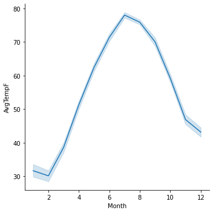

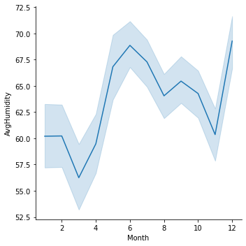

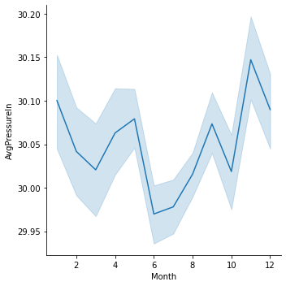

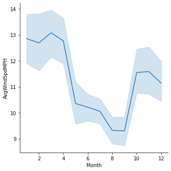

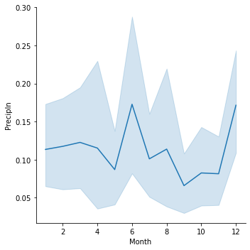

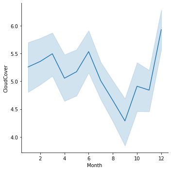

```python
cols = X.columns
for i in range(0,6): # range over each X column (exclude dummy variables)
    sns.relplot(data=X_monthly, x="Month", y=cols[i], kind="line");
#sns.relplot(data=X_monthly, x="Month", y="AvgTempF", kind = "line");
```

While the precipitation was before said to be more in the summer than winter (and thus categorizing the city as a subtropical climate), there are large fluctuations in the data making it difficult to prove any correlation between the time of year and expected precipitation without further analysis.

We can also plot the temperature distribution using a box and whiskers plot to observe the respective data distributions of each month. As observed, the overall cyclical trend is reproduced but a large IQR is found in the winter months suggesting the region to be prone to intense and longer lasting periods of extreme hot or cold weather, likely brought by tropical storm activity or from the westerlies. This is inferred based on the climate classification and the above data showing large wind speeds in these months.

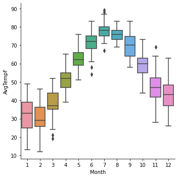

```python
sns.catplot(data=X_monthly,
    x="Month", y="AvgTempF",
    kind="box"
    );
```

The number of vehicle collisions can be plotted versus time to show the relationship to the time of year and vehicle collisions.

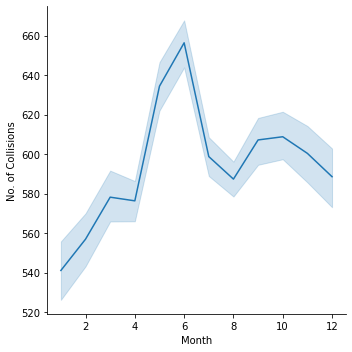

```python
# use daily_count3 to get a longer range view
daily_count3['Month'] = pd.DatetimeIndex(daily_count3['Date']).month # add a month column

sns.relplot(data=daily_count3,
    x="Month", y="No. of Collisions",
    kind = "line",
    );
```

It is observed in the plot above that the number of vehicle collisions peaks in the month of June and is at a minimum in January. This is most likely explained by the increased number of drivers on the road during warmer, summer months compared to colder, winter months. This is an important bias to the data as the time of year correlates very strongly to the temperature and thus it would suggest that the temperature would have a high correlation with the number of vehicle collisions.

## 4 Correlations

### 4.1 One-Dimensional Feature Dependency

It has yet to be established whether the current features used for classification are completely independent from one another. This is vital to improving the efficiency of the classification algorithm as increasing the input features will drastically increase the computational time and can lead to misleading results as well. Therefore, it is imperitive to determine how the features are correlated with respect to one another.

```python
print("Weather Features: ")
print(*np.array(X.columns), sep = ", ")
```

```
Weather Features:
AvgTempF, AvgHumidity, AvgPressureIn, AvgWindSpdMPH, PrecipIn, CloudCover, Is_Rain, Is_Snow, Is_Fog, Is_Storm
```

For each feature listed above, a pair plot can be created. The first six are plotted together as these are the features with meaningful graphical comparisons items worth comparing.

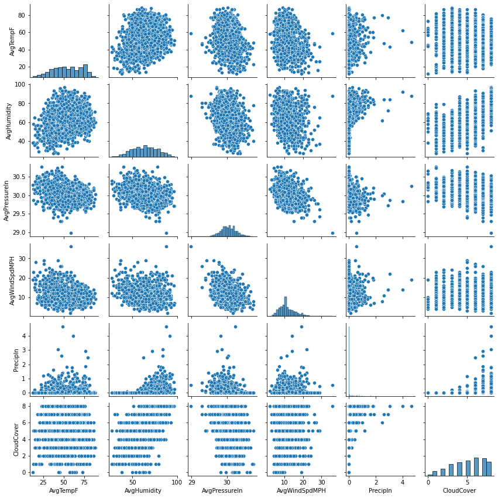

```python
cols = X.columns[0:6]

sns.pairplot(data=X[cols], height=2);
```

There is no expected correlation between the weather event, such as fog or rain, and the other quantitative data, such as temperature, wind speed, as the event data are dummy variables to classify the weather events of the day and can only be a 1 or 0. Some notable expectations are the lack of high temperature snow days, low pressure no-rain days, and low humidity rain days. To verify this, the comparisons between the precipitation features (or weather events) and the remaining five features can be shown in a pairwise plot below. A total of 20 of such plots are created but are commented out to avoid clutter.

```python
'''
events = ['Is_Rain', 'Is_Snow', 'Is_Fog', 'Is_Storm']
other_weather = ['AvgTempF', 'AvgHumidity', 'AvgPressureIn', 'AvgWindSpdMPH', 'CloudCover']

for i in range(len(events)): # for each weather event
    for j in range(len(other_weather)): # for each weather feature
        sns.relplot(data=X, x=events[i], y=other_weather[j]);
'''
```

```
"\nevents = ['Is_Rain', 'Is_Snow', 'Is_Fog', 'Is_Storm']\nother_weather = ['AvgTempF', 'AvgHumidity', 'AvgPressureIn', 'AvgWindSpdMPH', 'CloudCover']\n\nfor i in range(len(events)): # for each weather event\n    for j in range(len(other_weather)): # for each weather feature\n        sns.relplot(data…
```

The correlation between weather events occuring simultaneously can be established. The total number of occurences for each possible weather event combination is shown below, sorted by occurence.

```
Rain                      275
Snow                       58
Fog-Rain                   52
Rain-Thunderstorm          52
Rain-Snow                  32
Fog                        18
Fog-Rain-Snow              13
Fog-Snow                    5
Fog-Rain-Thunderstorm       5
Thunderstorm                1
Fog-Thunderstorm            1
Rain-Snow-Thunderstorm      1
Name: Events, dtype: int64
```

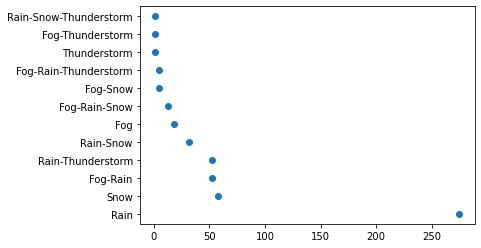

```python
event_count = weather2["Events"].value_counts()
print(event_count)
plt.scatter(event_count, event_count.index);
```

In order to prove two weather events are correlated, it must be concluded that 1) for most X, Y occurs, and 2) for most Y, X occurs. For example, almost all thunderstorms are accompanied by rain, as shown by the small frequency of thunderstorms occuring alone compared to the larger frequency of Rain-Thunderstorm and Fog-Rain-Thunderstorm pairs. However, thunderstorms cannot be removed as a feature as the high frequency of Rain and Fog-Rain pairs would make the dependence of Thunderstorms on Fog and Rain hard to predict. There is no clear parameter which is obsolete from this analysis so each weather event is considered for classification purposes.

A similar way to reach this conclusion is by creating a Venn diagram between each of the four events and finding the respective areas of the overlapping regions compared to the entire event section--for example, as there is little overlap between the Rain days and other weather event days compared to the total number of Rain occurences, this feature cannot be ignored.

A data table of the spearman coefficients between any two weather features are calculated in order to verify these conclusions.

```python
full_spearman = X.corr(method = 'spearman') # compute spearman correlation

for i in range(len(X.columns)):
    for j in range(len(X.columns)):
        if i==j:
            full_spearman.iloc[i,j] = None # remove all values on diagonal

full_spearman
```

|  | AvgTempF | AvgHumidity | AvgPressureIn | AvgWindSpdMPH | PrecipIn | CloudCover | Is_Rain | Is_Snow | Is_Fog | Is_Storm |
| --- | --- | --- | --- | --- | --- | --- | --- | --- | --- | --- |
| AvgTempF | NaN | 0.276427 | -0.242008 | -0.251217 | -0.029748 | -0.054441 | 0.107183 | -0.411795 | -0.069609 | 0.236140 |
| AvgHumidity | 0.276427 | NaN | -0.221299 | -0.215239 | 0.583763 | 0.625396 | 0.566843 | -0.005344 | 0.343545 | 0.214482 |
| AvgPressureIn | -0.242008 | -0.221299 | NaN | -0.284828 | -0.284235 | -0.211834 | -0.302258 | -0.088026 | -0.112153 | -0.189865 |
| AvgWindSpdMPH | -0.251217 | -0.215239 | -0.284828 | NaN | 0.069912 | -0.045296 | 0.035806 | 0.151964 | -0.041808 | -0.034684 |
| PrecipIn | -0.029748 | 0.583763 | -0.284235 | 0.069912 | NaN | 0.621792 | 0.761792 | 0.211847 | 0.281316 | 0.330087 |
| CloudCover | -0.054441 | 0.625396 | -0.211834 | -0.045296 | 0.621792 | NaN | 0.615265 | 0.213627 | 0.245711 | 0.155206 |
| Is_Rain | 0.107183 | 0.566843 | -0.302258 | 0.035806 | 0.761792 | 0.615265 | NaN | 0.037411 | 0.231971 | 0.289359 |
| Is_Snow | -0.411795 | -0.005344 | -0.088026 | 0.151964 | 0.211847 | 0.213627 | 0.037411 | NaN | 0.100422 | -0.060783 |
| Is_Fog | -0.069609 | 0.343545 | -0.112153 | -0.041808 | 0.281316 | 0.245711 | 0.231971 | 0.100422 | NaN | 0.017158 |
| Is_Storm | 0.236140 | 0.214482 | -0.189865 | -0.034684 | 0.330087 | 0.155206 | 0.289359 | -0.060783 | 0.017158 | NaN |

```python
# track current maximum value and position
max_val = 0
max_val_pos = [0,0]
# loop over all values in table to find maximum
for i in range(len(X.columns)):
    for j in range(len(X.columns)):
        if abs(full_spearman.iloc[i,j]) > max_val:
            max_val = full_spearman.iloc[i,j] # save new max
            max_val_pos = [i,j]

print('Most correlated features: ' + str(X.columns[max_val_pos[0]]) + ' and ' + str(X.columns[max_val_pos[1]]) )
print('Corresponding spearman coefficient: ' + str(max_val))
```

```
Most correlated features: PrecipIn and Is_Rain
Corresponding spearman coefficient: 0.7617920864237233
```

The highest correlated features are the reported precipitation and the occurence of rain, as expected. However, as described before, the "Is_Rain" feature is needed to specify the specific type of precipitation which creates a hazardous condition. Besides this, the next best correlated features are the cloud coverage and the average humidity, which only have a correlation of 0.625. Therefore, all features are necessary for computation and thus considered uncorrelated.

### 4.2 Two-Dimensional Feature Dependency

It was established that none of the parameters are dependent directly upon any of the others, e.g. rain cannot be expressed as a function of pressure. However, the above analysis did not consider whether multiple features can combine to correlate to another feature. For example, high amounts of precipitation on its own does not correspond to the pressence of a storm, but high precipitation and low pressure might. It is computationally exhaustive to compute each pairwise relation and their effect on weather events, but educated guesses can be employed to determine this two-factor correlation.

```
Pressure vs Temp for Snow Occurence
spearman coeff. w/ snow: -0.17878996089695212
spearman coeff. w/o snow: -0.3144606791051107
```

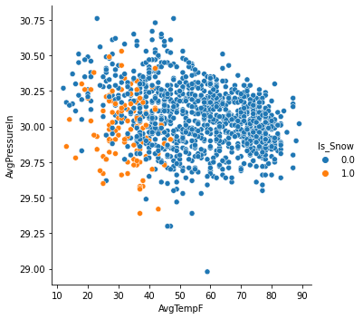

```
Wind Speed vs Pressure for Storm Occurence
spearman coeff. w/ storm: -0.3725827041242697
spearman coeff. w/o storm: -0.2932232506528725
```

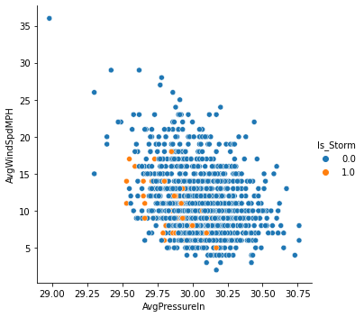

```
Precipitation vs Pressure for Storm Occurence
spearman coeff. w/ storm: -0.13826739455694717
spearman coeff. w/o storm: -0.23667109437839273
```

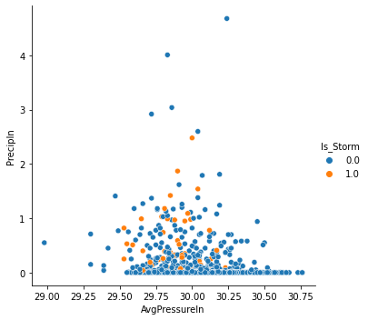

```
Humidity vs Cloud Coverage for Rain Occurence
spearman coeff. w/ rain: 0.6470294494629876
spearman coeff. w/o rain: 0.35438050802803356
```

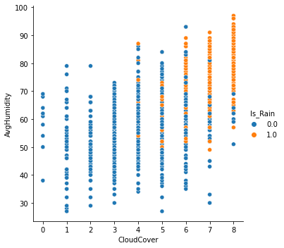

```python
print("Pressure vs Temp for Snow Occurence")
sns.relplot(data=X, x="AvgTempF", y="AvgPressureIn", hue="Is_Snow"); # plot pressure vs precipitation with hues as storm

snow_occ = X[X["Is_Snow"] == 1] # data which snow occurs
snow_no_occ = X[X["Is_Snow"] == 0] # data which no snow occurs
print("spearman coeff. w/ snow: " + str(snow_occ["AvgTempF"].corr(snow_occ["AvgPressureIn"],"spearman")))
print("spearman coeff. w/o snow: " + str(snow_no_occ["AvgTempF"].corr(snow_no_occ["AvgPressureIn"],"spearman")))
plt.show()
print('')


print("Wind Speed vs Pressure for Storm Occurence")
sns.relplot(data=X, x="AvgPressureIn", y="AvgWindSpdMPH", hue="Is_Storm"); # plot pressure vs wind speed with hues as storm

storm_occ = X[X["Is_Storm"] == 1] # data which storm occurs
storm_no_occ = X[X["Is_Storm"] == 0] # data which no storm occurs
print("spearman coeff. w/ storm: " + str(storm_occ["AvgPressureIn"].corr(storm_occ["AvgWindSpdMPH"],"spearman")))
print("spearman coeff. w/o storm: " + str(storm_no_occ["AvgPressureIn"].corr(storm_no_occ["AvgWindSpdMPH"],"spearman")))
plt.show()
print('')


print("Precipitation vs Pressure for Storm Occurence")
sns.relplot(data=X, x="AvgPressureIn", y="PrecipIn", hue="Is_Storm"); # plot pressure vs precipitation with hues as storm

print("spearman coeff. w/ storm: " + str(storm_occ["AvgPressureIn"].corr(storm_occ["PrecipIn"],"spearman")))
print("spearman coeff. w/o storm: " + str(storm_no_occ["AvgPressureIn"].corr(storm_no_occ["PrecipIn"],"spearman")))
plt.show()
print('')


print("Humidity vs Cloud Coverage for Rain Occurence")
sns.relplot(data=X, x="CloudCover", y="AvgHumidity", hue="Is_Rain"); # plot cloud coverage vs humidity with hues as rain

rain_occ = X[X["Is_Rain"] == 1] # data which rain occurs
rain_no_occ = X[X["Is_Rain"] == 0] # data which no rain occurs
print("spearman coeff. w/ rain: " + str(rain_occ["CloudCover"].corr(storm_occ["AvgHumidity"],"spearman")))
print("spearman coeff. w/o rain: " + str(rain_no_occ["CloudCover"].corr(storm_no_occ["AvgHumidity"],"spearman")))
plt.show()
```

As observed in the above graphs, there are no strong correlations between three connected features of the weather data. The highest correlated relation found was between the occurence of rain to a position on the average humidity & cloud coverage feature space (0.647 for data with rain, 0.354 for data without rain). However, this is still not a high enough correlation to completely disregard the rain weather event and thus the rain event must be considered independently of the other features in order to create a classification algorithm. This is true for the storm and rain events observed above. Note that this is a large simplification of the data but provides a first order approximation of how strongly the features are intercorrelated. For higher order correaltion, and for more complex predictions, the classification algorithm must be used as the calculations shown above suggest weak correlations between all features.

### 4.3 Label Correlation

The correlation between each weather parameter and the amount of reported vehicle collisions can be assessed. A correlation plot is given between the individual parameter (X-axis) and the number of total collisions (Y-axis)--for each plot, the Pearson and Spearman correlation coefficients are reported as well. For the specific weather events, the correlations are directly computed as these are categorical data quantified by binary dummy classifiers and thus plotted data would not be as representative.

```
No. of collisions vs. AvgTempF
Pearson Coeff.: 0.20467144652139668
Spearman Coeff.: 0.23901028163707264
```

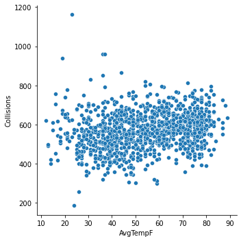

```
No. of collisions vs. AvgHumidity
Pearson Coeff.: 0.08215998681606174
Spearman Coeff.: 0.08004977307082761
```

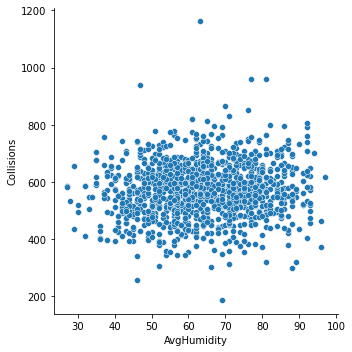

```
No. of collisions vs. AvgPressureIn
Pearson Coeff.: -0.028578100529787716
Spearman Coeff.: -0.04203623218258776
```

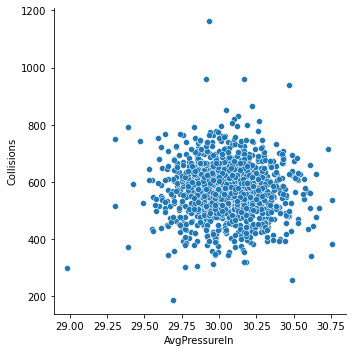

```
No. of collisions vs. AvgWindSpdMPH
Pearson Coeff.: -0.03889247226056687
Spearman Coeff.: -0.030474391389913476
```

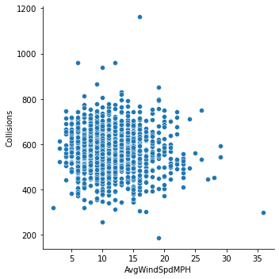

```
No. of collisions vs. PrecipIn
Pearson Coeff.: 0.1732000911740921
Spearman Coeff.: 0.0940116119954689
```

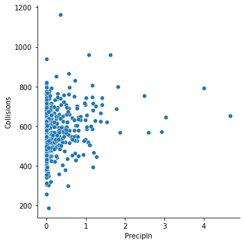

```
No. of collisions vs. CloudCover
Pearson Coeff.: -0.0623599947930078
Spearman Coeff.: -0.07306310534018964
```

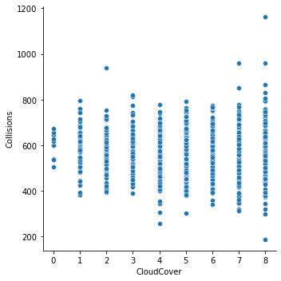

```
No. of collisions vs. Is_Rain
Pearson Coeff.: 0.07321402775491874
Spearman Coeff.: 0.06373261383027515

No. of collisions vs. Is_Snow
Pearson Coeff.: -0.07387382158194554
Spearman Coeff.: -0.10681662185406175

No. of collisions vs. Is_Fog
Pearson Coeff.: 0.021309140379378786
Spearman Coeff.: 0.0017503268421786807

No. of collisions vs. Is_Storm
Pearson Coeff.: 0.09826594937604892
Spearman Coeff.: 0.1060325779368204
```

```python
X_var = pd.Series(X.columns, name = "feature") # all weather features

pearsons = []
spearmans = []
for i in range(len(X_var)): # loop over each feature
    print("No. of collisions vs. " + str(X_var[i]) )

    # print the coefficients
    print("Pearson Coeff.: " + str(X[X_var[i]].corr(Xy['Collisions'], "pearson")))
    print("Spearman Coeff.: " + str(X[X_var[i]].corr(Xy['Collisions'], "spearman")))

    # add to list of coefficients
    pearsons.append(X[X_var[i]].corr(Xy['Collisions'], "pearson"))
    spearmans.append(X[X_var[i]].corr(Xy['Collisions'], "spearman"))

    # display plot
    if i < len(X_var) - 4: # non-categorical data
        sns.relplot(data=Xy, x=X_var[i], y='Collisions')
        plt.show()

    print('')
```

The Pearson and Spearman coefficients for each metric are summarized in the table shown below.

```python
# convert lists to series
pearsons_s = pd.Series(pearsons, name = "pearsons_s")
spearmans_s = pd.Series(spearmans, name = "spearmans_s")

coeff = pd.concat([X_var, pearsons_s, spearmans_s], axis=1) # convert to dataframe

coeffs = coeff.rename(columns={"pearsons_s" : "pearson", "spearmans_s" : "spearman"}) # rename columns
coeffs = coeffs.set_index("feature") # index by weather feature

coeffs.head(10)
```

| feature | pearson | spearman |
| --- | --- | --- |
| AvgTempF | 0.204671 | 0.239010 |
| AvgHumidity | 0.082160 | 0.080050 |
| AvgPressureIn | -0.028578 | -0.042036 |
| AvgWindSpdMPH | -0.038892 | -0.030474 |
| PrecipIn | 0.173200 | 0.094012 |
| CloudCover | -0.062360 | -0.073063 |
| Is_Rain | 0.073214 | 0.063733 |
| Is_Snow | -0.073874 | -0.106817 |
| Is_Fog | 0.021309 | 0.001750 |
| Is_Storm | 0.098266 | 0.106033 |

From the table of correlation coefficients for each of the weather feature metrics, there is virtually no correlation between any of the metrics and the number of vehicle collisions. A classification algorithm will be applied to see if there is an accurate way to determine the collisions using all of the features combined. The most important feature of the classification algorithm can be determined to suggest the effect of different weather features on vehicle collisions.

## 5 Classification Algorithm

### 5.1 Data Preparation and Algorithm Selection

For this classification algorithm, a k-nearest neighbors (KNN) algorithm is used as the complexity of the feature matrix requires a more complex algorithm. While the size of the data set favors the computationally simpler decision tree algorithm compared to the kNN algorithm, the low correlation found between each feature and the number of collisions suggests that the algorithm will need to use all features of different weights to determine the label and thus the kNN algorithm is best.

As the kNN algorithm uses a distance heuristic, standardization of data is required to remove any bias against larger values of the data set and instead fix each feature to a specific range. This is performed by using a pipeline to take the z-score of all values in the dataframe. The z-score is computed by $ z = (x - \mu)/\sigma $ where x is the data value, $\mu$ is the mean of the feature series x is an element of, and $\sigma$ is the standard deviation of that series.

The label series is given as numerical data, but must be converted to categorical data in order to classify. Outliers can be determined using the 1.5IQR rule; this is also used to determine good positions to split the data for the categories.

```
Daily Collision Data
count    1176.000000
mean      570.761054
std        95.460790
min       188.000000
25%       510.750000
50%       571.000000
75%       629.250000
max      1161.000000
Name: Collisions, dtype: float64

Number of outliers: 17
```

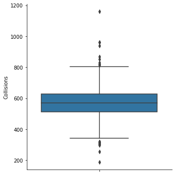

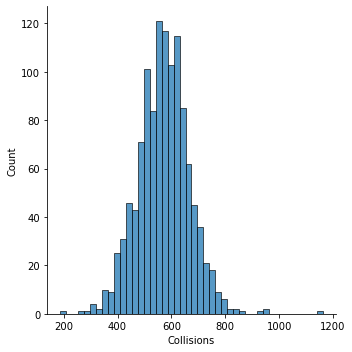

```python
sns.catplot(data=Xy,
    y="Collisions",
    kind="box"
);

sns.displot(data=Xy,
    x="Collisions"
    );

print('Daily Collision Data')
y_desc = pd.Series(Xy["Collisions"].describe())
print(y_desc.head(10))

num_out = 0 # number of outliers
p25 = float(y_desc[4]) # 25th percentile
p75 = float(y_desc[6]) # 75th percentile

for i in range(len(y)): # loop over each label ent
    val = y.iloc[i][0]
    if val > (p75 + 1.5*(p75-p25)) or val < (p25 - 1.5*(p75-p25)):
        num_out+=1

print("")
print("Number of outliers: " + str(num_out))
```

As shown in the plots and calculations above, there are a few outliers which will be removed from the data set in order to create results more representative of the population at hand.

```python
IQR = p75 - p25
min_outlier = p25 - 1.5*IQR # compute outlier bounds
max_outlier = p75 + 1.5*IQR

# boolean statements for filtering, True if in allowable 1.5IQR range
is_not_outlier_min = (Xy["Collisions"] > min_outlier)
is_not_outlier_max = (Xy["Collisions"] < max_outlier)

Xy2 = Xy # copy data

# apply filters
Xy2 = Xy[is_not_outlier_min & is_not_outlier_max]

Xy = Xy2 # update dataframes

X = Xy[["AvgTempF", "AvgHumidity", "AvgPressureIn", "AvgWindSpdMPH", "PrecipIn", "CloudCover", "Is_Rain", "Is_Snow","Is_Fog","Is_Storm"]]
X.head(5)
```

| Date | AvgTempF | AvgHumidity | AvgPressureIn | AvgWindSpdMPH | PrecipIn | CloudCover | Is_Rain | Is_Snow | Is_Fog | Is_Storm |
| --- | --- | --- | --- | --- | --- | --- | --- | --- | --- | --- |
| 2012-10-12 | 52.0 | 58.0 | 30.20 | 15.0 | 0.00 | 3.0 | 0.0 | 0.0 | 0.0 | 0.0 |
| 2012-10-13 | 46.0 | 44.0 | 30.45 | 9.0 | 0.00 | 2.0 | 0.0 | 0.0 | 0.0 | 0.0 |
| 2012-10-14 | 64.0 | 69.0 | 30.15 | 17.0 | 0.00 | 6.0 | 0.0 | 0.0 | 0.0 | 0.0 |
| 2012-10-15 | 65.0 | 83.0 | 29.75 | 14.0 | 0.18 | 7.0 | 1.0 | 0.0 | 0.0 | 0.0 |
| 2012-10-16 | 55.0 | 62.0 | 29.79 | 15.0 | 0.00 | 3.0 | 0.0 | 0.0 | 0.0 | 0.0 |

```python
y = Xy[["Collisions"]]
y.head(5)
```

| Date | Collisions |
| --- | --- |
| 2012-10-12 | 594 |
| 2012-10-13 | 547 |
| 2012-10-14 | 517 |
| 2012-10-15 | 607 |
| 2012-10-16 | 602 |

The data now must be divided into categories for classification. Five categories are used to create a good balance between having minimal categorical features for easier computation yet still having ample distinction between data points. This is modelled after a common five point Likert scale used in survery questionaires [5], for example. Values left of the median (< 50th percentile of total daily collisions) will be referred to negative collision days in reference to having a negative z-score for the number of collisions. Values right of the median (> 50th percentile of total daily collisions) will be referred to as positive collision days for similar reasoning. Values near the median (between the 40th and 60th percentile) are referred to as being median collision days for relatively low z-scores. The nomeclature used for classification is shown below.

```python
label_types = pd.DataFrame(data =
    {'Symbol' : ['N', 'n', 'M', 'p', 'P'],
     "Name" : ['Very negative', 'Moderately negative', 'Median', 'Moderately positive', 'Very positive'],
     "Percentile Range" : [' 0 <= p <  20 ', '20 <= p <  40 ', '40 <= p <= 60 ', '60  < p <= 80 ', '80  < p <= 100'] }
    )

label_types.head()
```

|  | Symbol | Name | Percentile Range |
| --- | --- | --- | --- |
| 0 | N | Very negative | 0 <= p < 20 |
| 1 | n | Moderately negative | 20 <= p < 40 |
| 2 | M | Median | 40 <= p <= 60 |
| 3 | p | Moderately positive | 60 < p <= 80 |
| 4 | P | Very positive | 80 < p <= 100 |

Note that each label has roughly equal population size by design (20th percentile ranges), giving the base classification algorithm (i.e., were it to just blindly predict each day) equal liklihood to predict a given days total number of collisions. Each value of the label series is categorized according to the scheme described above.

```python
labels = pd.Series(y["Collisions"]) # convert to series

# compute percentiles for divisions
p20 = float(y.quantile(q=0.2))
p40 = float(y.quantile(q=0.4))
p50 = float(y.quantile(q=0.5))
p60 = float(y.quantile(q=0.6))
p80 = float(y.quantile(q=0.8))

print("Percentiles: " + "20th = " + str(p20) + ", 40th = " + str(p40) + ", 60th = " + str(p60) + ", 80th = " + str(p80))

yc_list = [] # label list
for i in range(len(y)):
    val = y.iloc[i][0]
    if val < p20:
        yc_list.append('N')
    if val >= p20 and val < p40:
        yc_list.append('n')
    if val >= p40 and val <= p60:
        yc_list.append('M')
    if val > p60 and val <= p80:
        yc_list.append('p')
    if val > p80:
        yc_list.append('P')

yc = pd.Series(data = yc_list, name = "yc", index = y.index) # convert to series

# display labels to make sure they make sense
yc_frame = pd.DataFrame(data={"Collisions" : y["Collisions"], "Label" : yc}, index = Xy.index)
yc_frame
```

```
Percentiles: 20th = 496.0, 40th = 549.0, 60th = 595.0, 80th = 645.0
```

| Date | Collisions | Label |
| --- | --- | --- |
| 2012-10-12 | 594 | M |
| 2012-10-13 | 547 | n |
| 2012-10-14 | 517 | n |
| 2012-10-15 | 607 | p |
| 2012-10-16 | 602 | p |
| ... | ... | ... |
| 2015-12-27 | 518 | n |
| 2015-12-28 | 490 | N |
| 2015-12-29 | 533 | n |
| 2015-12-30 | 501 | n |
| 2015-12-31 | 527 | n |

1159 rows × 2 columns

### 5.2 Single k-Nearest Neighbors Classification

For a starting point, an arbitrary $n = 3$ neighbors are used for the kNN algorithm. This value will be optimized in later sections but for now provides a basis for analysis. The data is divided into training and testing sets of data with the testing being 20% of the total dataset. A random shuffle state is also used to evaluate performance later.

```python
X_train, X_test, y_train, y_test = train_test_split(
    X, yc,
    test_size=0.2,
    shuffle=True,
    random_state=43913,
); # split data (features and categorical labels) between testing and training data

# if KNN
knn = KNeighborsClassifier(n_neighbors=3, weights = "distance", p = 2); # use kNN algorithm, euclidean distance
pipe = make_pipeline(StandardScaler(), knn); # standardize data

# if tree
#tree = DecisionTreeClassifier(max_depth=1) # code if using
#pipe = make_pipeline(StandardScaler(), tree); # standardize data

pipe.fit(X_train, y_train); # train pipeline

yhat = knn.predict(X_test); # make predictions using trained data

pd.Series(yhat, index = y_test.index).head(10) # display predicted data
```

```
Date
2013-02-24    P
2014-08-26    M
2015-06-03    M
2013-11-12    P
2014-02-11    n
2015-05-06    M
2014-06-26    M
2014-03-26    P
2014-01-11    P
2014-11-06    M
dtype: object
```

A confusion matrix is created using the predicted values from the algorithm. A one-versus-all method is used to compute the precision score for each label--this is averaged for each label and reported as the average precision value shown below.

```
Average precision (single): 0.14396147944762983
```

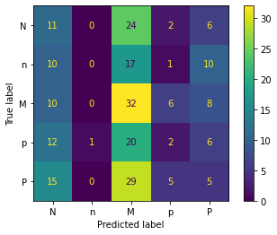

```python
label_symbols = ['N', 'n', 'M', 'p', 'P'] # all possible labels

# compute and display confusion matrix
C = confusion_matrix(y_test, yhat, labels=label_symbols)
ConfusionMatrixDisplay(C, display_labels=label_symbols).plot();

pr_all = precision_score(y_test, yhat, average="macro", zero_division = 0)
print('Average precision (single): ' + str(pr_all) )
```

In the confusion matrix above, it is observed that the algorithm has difficulty predicting collision totals outside of the moderate range. With varying the n for the kNN algorithm, this becomes more apparent. This is likely caused by the large variation in weather data which makes classification hard--a median prediction the best outcome to minimize the error on average so this data sees increased predictions. A good number of predicitions also occurs with the "very negative" label with minimal number of crashes. This could be suggestive of certain weather data closely aligning with wintry weather which has been observed to have much less collisions.

An ROC curve can be generated which is used to describe how well the algorithm predicts the data without having erronous false positives. The AUC score is generated corresponding to this plot as well.

```
AUC score (single classifier) = 0.498915
```

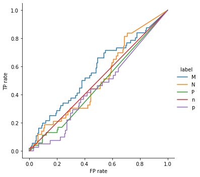

```python
p_hat = knn.predict_proba(X_test) # probabilistic interpretation

# calculate true and false positive rates for a variety of theta values
results = []
for i, label in enumerate(knn.classes_):
    actual = (y_test==label)
    fp, tp, theta = roc_curve(actual,p_hat[:,i])
    results.extend( [(label,fp,tp) for fp,tp in zip(fp,tp)] )
roc = pd.DataFrame( results, columns=["label","FP rate","TP rate"] )

sns.relplot(data=roc,
    x="FP rate", y="TP rate",
    hue="label", kind="line", estimator=None
    );

# compute auc score
auc = roc_auc_score(y_test, p_hat, average = 'macro', multi_class = 'ovr')
print(f"AUC score (single classifier) = {auc:.6f}")
```

For the single classifier, the algorithm does a poor job in predicting the correct label on average across all labels.

### 5.3 Ensemble k-Nearest Neighbors Classification

An ensemble is created to remove the bias of any single classification on the final precision score or AUC score. A training set of 80% of the allocated training dataset is used with using 50 different estimators and drawings as replacement. A confusion matrix can be generated as before using the ensemble to predict the classification of each testing data point.

```
Average precision (ensemble): 0.2066064887493459
```

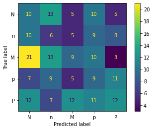

```python
ensemble = BaggingClassifier(
    pipe,
    max_samples=0.8,
    n_estimators=50,
    random_state=4912
    ) # create ensemble

ensemble.fit(X_train, y_train); # train ensemble

yhat_e = ensemble.predict(X_test); # ensemble prediction

C = confusion_matrix(y_test, yhat_e, labels=label_symbols)
ConfusionMatrixDisplay(C, display_labels=label_symbols).plot();

pr_all_e = precision_score(y_test, yhat_e, average="macro", zero_division = 0)
print('Average precision (ensemble): ' + str(pr_all_e) )
```

A slight increase in precision is observed using this ensemble method, but the algorithm as a whole does a very poor job in predicitng the data as shown. The ROC curve and associated AUC score can be generated to compare directly to the results from the single classifier analysis.

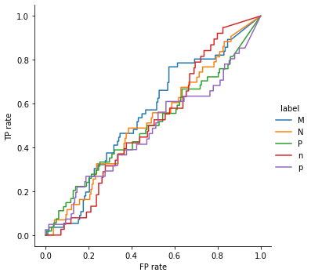

```python
phat_e = ensemble.predict_proba(X_test); # ensemble probabilistic prediction

# calculate true and false positive rates for a variety of theta values
results = []
for i, label in enumerate(ensemble.classes_):
    actual = (y_test==label)
    fp, tp, theta = roc_curve(actual,phat_e[:,i])
    results.extend( [(label,fp,tp) for fp,tp in zip(fp,tp)] )
roc = pd.DataFrame( results, columns=["label","FP rate","TP rate"] )

sns.relplot(data=roc,
    x="FP rate", y="TP rate",
    hue="label", kind="line", estimator=None
    );
```

```python
auc = roc_auc_score(y_test, phat_e, average = 'macro', multi_class = 'ovr')
print(f"AUC score (ensemble classifier) = {auc:.6f}")
```

```
AUC score (ensemble classifier) = 0.511558
```

Again, the ensemble method does improve the results, but the improvement is very slight suggesting that the data is either too complex to analyze or has much too much noise to give meaningful predictions. The distribution of predictions in the confusion matrix shown above suggests the algorithm to be randomly guessing each label which creates the poor results observed.

## 6 Performance Evaluation

### 6.1 Hyperparameter Optimization

While the kNN algorithm from before used $n=3$, this hyperparameter can be optimized using cross-validation. For a large range of $n$ for the kNN algorithm, the $n$ with the best balanced accuracy score is determined to be the best hyperparameter to use for the classification algorithm. A total of 6 stratified folds are used as shown below.

```python
kf = StratifiedKFold(n_splits=6, shuffle=True, random_state=15321)
scores = cross_validate(
    pipe,
    X_train, y_train,
    cv=kf,
    scoring="balanced_accuracy"
    )

print("Validation scores:")
print( scores["test_score"] )

print('')
print("Validation score st. dev: " + str(np.std(scores["test_score"]))) # display standard deviation
```

```
Validation scores:
[0.23125695 0.22614016 0.21190211 0.19554876 0.24601641 0.22170467]

Validation score st. dev: 0.01571246126302048
```

There is low variance in the validation scores, suggesting the data to be decently representative of the overall data set. However, the low values suggest the algorithm to be largely innaccurate.

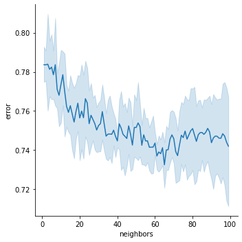

```python
neighbors = range(1, 100, 1) # check all neighbors from n=1 to n=12

results = []
for n in neighbors:
    knn = KNeighborsClassifier(n_neighbors=n, weights = "distance", p = 2)
    cv = cross_validate(knn,
        X_train, y_train,
        cv=kf,
        scoring="balanced_accuracy",
        n_jobs=-1
        )
    for err in (1 - cv["test_score"]):
      results.append( (n, err) )

results = pd.DataFrame(results, columns=["neighbors", "error"] )
sns.relplot(data=results,
    x="neighbors", y="error",
    kind="line"
    );
```

The number of neighbors with the minimum associated error (measured by the balanced accuracy score) is used for the nearest neighbors algorithm. This value can be found by aggregating the data presented above to find the average error based on the number of nearest neighbors.

```python
errors = results.set_index('neighbors') # use neighbors as index

error_agg = errors.groupby("neighbors")["error"].describe()['mean'] # group data by neighbors, find mean of aggregate

print(error_agg.head())

print('')
index_best_n = error_agg.argmin()
print('Optimal n: ' + str(neighbors[index_best_n]) )
print('Associated error: ' + str(error_agg.iloc[index_best_n]) )
```

```
neighbors
1    0.783605
2    0.783605
3    0.783928
4    0.781273
5    0.782426
Name: mean, dtype: float64

Optimal n: 65
Associated error: 0.7325304350512916
```

Therefore, a kNN algorithm with n=65 is the most error-minimizing method of classifying the data. This n value is used to maximize the precision score and AUC score. As the ensemble method was superior to the single classifier in both these metrics, this is used as well. The same test-train data split is used as before.

```
Average precision (ensemble): 0.2505324756544268
```

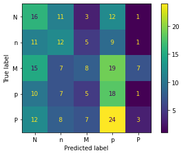

```python
knn = KNeighborsClassifier(n_neighbors=65, weights = "distance", p = 2); # use kNN algorithm, euclidean distance
pipe = make_pipeline(StandardScaler(), knn); # standardize data

ensemble = BaggingClassifier(
    pipe,
    max_samples=0.8,
    n_estimators=50,
    random_state=4912
    ) # create ensemble

ensemble.fit(X_train, y_train); # train ensemble

yhat_e = ensemble.predict(X_test); # ensemble prediction

C = confusion_matrix(y_test, yhat_e, labels=label_symbols)
ConfusionMatrixDisplay(C, display_labels=label_symbols).plot();

pr_all_e = precision_score(y_test, yhat_e, average="macro", zero_division = 0)
print('Average precision (ensemble): ' + str(pr_all_e) )
```

As before, the AUC score can be computed as an average over the performance in classifying each label.

```python
p_hat_e = ensemble.predict_proba(X_test) # probabilistic characterization, ensemble

auc = roc_auc_score(y_test, p_hat_e, average = 'macro', multi_class = 'ovr')
print(f"AUC score (ensemble classifier) = {auc:.6f}")
```

```
AUC score (ensemble classifier) = 0.564489
```

There is marginal improvement from before for this algorithm. This suggests the previous explanation to be true in that the data is too noisy, uncorrelated, or sparse to get accuracy classifications.

### 6.2 Grid Search Optimization

While the number of neighbors was optimized for algorithm performance, the hyperparameters of using a uniform or distance weighting scheme as well as the hyperparameter for the distance model used (if distance weighting is applied) can also be varied. This creates a 3D search space for n, the weighting type, and weighting model which is used to compute the overall best balanced accuracy score.

```python
# total grid search space
grid = { "n_neighbors":range(1,150,1),
         "weights":['uniform', 'distance'],
         "p": [1,2]}

knn = KNeighborsClassifier(); # kNN algorithm based on grid search

kf = StratifiedKFold(n_splits=4, shuffle=True, random_state=302)

grid_dt = GridSearchCV(
    knn, grid,
    scoring="balanced_accuracy",
    cv=kf,
    n_jobs=-1
    )
grid_dt.fit(X_train, y_train)

print("Best parameters:")
print(grid_dt.best_params_)
print()
print("Best score:")
print(grid_dt.best_score_)
```

```
Best parameters:
{'n_neighbors': 111, 'p': 1, 'weights': 'uniform'}

Best score:
0.28887508727530886
```

This is thus the best possible learning algorithm for the data based on all hyperparameters. The averaged ensemble precision score and AUC score are computed once again.

```
Ideal average precision (ensemble): 0.19542002380148277
Ideal AUC score (ensemble) = 0.572560
```

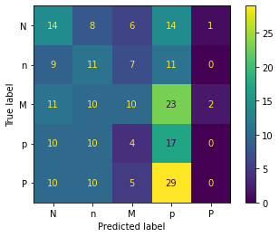

```python
# Confusion Matrix,
knn = KNeighborsClassifier(n_neighbors=111, weights = "uniform", p = 1); # use kNN algorithm based on optimal hyperparameters
pipe = make_pipeline(StandardScaler(), knn); # standardize data

ensemble = BaggingClassifier(
    pipe,
    max_samples=0.8,
    n_estimators=50,
    random_state=4912
    ) # create ensemble

ensemble.fit(X_train, y_train); # train ensemble

yhat_e = ensemble.predict(X_test); # ensemble prediction

C = confusion_matrix(y_test, yhat_e, labels=label_symbols)
ConfusionMatrixDisplay(C, display_labels=label_symbols).plot();

pr_all_e = precision_score(y_test, yhat_e, average="macro", zero_division = 0)
print('Ideal average precision (ensemble): ' + str(pr_all_e) )

# AUC score
p_hat_e = ensemble.predict_proba(X_test) # probabilistic characterization, ensemble

auc = roc_auc_score(y_test, p_hat_e, average = 'macro', multi_class = 'ovr')
print(f"Ideal AUC score (ensemble) = {auc:.6f}")
```

While the AUC score increased again from before, the average precision of the ensemble decreased. Both values are still exceptionally low and thus the algorithm does a poor job predicting the classification labels.

## 7 Conclusion and Discussion

The results of this study are largely inconclusive. First, correlations between each weather parameter and the total number of vehicle collisions were computed and it was determined that the temperature has the greatest correlation with predicting vehicle collisions, with a spearman coefficient of 0.239. While this is not a strong correlation, it corresponds to the fact that the number of vehicle collisions was strongly correlated to the time of year, with a cyclical trend observed where collisions peaked in June and saw a minimum in January. Therefore, as the temperature in this region peaks during the month of July and is at a minimum in February, it is likely that the correlation between the temperature and vehicle collisions is rather indicative of a third-variable problem of both being correlated to the time of year.

The correlation between the various weather events and features determined previously to be "hazardous" conditions is minimal-to-none. The likely explanation behind this is the large variability in the data itself as weather is notoriously unpredictable based on the large fluctuations day-to-day. Based on the noise of this data, the low correlation makes sense. Combined with the fairly low dataset size (around 1,000 elements), the noise provided a notable challenge to producing meaningul correlations. Using the current data set, the original hypothesis of poor weather conditions impacting vehicle collision totals is rejected.

For future research, the following suggestions are made for improvement. First, a large correlation between the time of year and the number of collisions was observed. While this may be a true phenomenom, this does not suggest that roads are inherently more dangerous during colder weather (barring different weather events like snow and ice), but rather that less drivers may be using the roads during wintry months. The number of collisions should therefore be normalized with the estimated number of drivers on the road for that day. For example, using data from New York City tollbooths to estimate the number of cars on the road as a function of daily grossed revenue, the amount of vehicle collisions per 1,000 drivers can be computed and give a more accurate measure of road conditions. Thus, the data aligns more with the scope of the project. The data is largely limited in terms of population size so a larger data set is needed. This was a reult of having drastic differences in data ranges for the collected data, so early vehicle collision reports or more recent weather reports could be used. Increasing the number of samples should reduce the error generated by the inherent noise in the data samples as well.

## 8 References

[1] Zoni Nation. (2016). Weather for 24 US Cities. Weather Undergound. Github. Retrieved April 5, 2023 from https://github.com/zonination/weather-us.

[2] City of New York. (2020, October 11). Motor Vehicle Collisions - Crashes. data.world. Retrieved April 5, 2023, from https://data.world/city-of-ny/h9gi-nx95

[3] Arnfield, A. John (2022, December 5). Köppen climate classification. Encyclopedia Britannica. https://www.britannica.com/science/Koppen-climate-classification

[4] Weatherbase. (n.d.). New York, New York. Weatherbase. Retrieved April 5, 2023, from https://www.weatherbase.com/weather/weather-summary.php3?s=330527&amp;cityname=New%2BYork%2C%2BNew%2BYork%2C%2BUnited%2BStates%2Bof%2BAmerica

[5] Momentive. (2023). Likert scale: Examples and how to use it. SurveyMonkey. Retrieved April 5, 2023, from https://www.surveymonkey.com/mp/likert-scale/